# Support Vector Machines(SVMs) Tutorial

Sonali Narang

11/12/2019

## Support Vector Machines(SVMs)

A Support Vector Machine (SVM) is a discriminative classifier formally defined by a separating hyperplane. Given labeled training data, the algorithm outputs an optimal hyperplane which categorizes new examples.

## The Breast Cancer Dataset

699 Observations, 11 variables Predictor Variable: Class–benign or malignant

```r
data(BreastCancer)

#bc = BreastCancer %>%
#  mutate_if(is.character, as.numeric)
#bc[is.na(bc)] = 0

BreastCancer_num = transform(BreastCancer, Id = as.numeric(Id),
                         Cl.thickness = as.numeric(Cl.thickness),
                         Cell.size = as.numeric(Cell.size),
                         Cell.shape = as.numeric(Cell.shape),
                         Marg.adhesion = as.numeric(Marg.adhesion),
                         Epith.c.size = as.numeric(Epith.c.size),
                         Bare.nuclei = as.numeric(Bare.nuclei),
                         Bl.cromatin = as.numeric(Bl.cromatin),
                         Normal.nucleoli = as.numeric(Normal.nucleoli),
                         Mitoses = as.numeric(Mitoses))

BreastCancer_num[is.na(BreastCancer_num)] = 0

train_size = floor(0.75 * nrow(BreastCancer_num))
train_pos <- sample(seq_len(nrow(BreastCancer_num)), size = train_size)

train_classification <- BreastCancer_num[train_pos, ]
test_classification <- BreastCancer_num[-train_pos, ]
```

## SVM

```r
set.seed(1112)
control = trainControl(method = "repeatedcv", repeats = 5, classProbs = T, savePredictions = T)

svm = train(Class ~ Id + Cl.thickness + Cell.size + Cell.shape + Marg.adhesion + Epith.c.size + Bare.nuclei + Bl.cromatin + Normal.nucleoli +  Mitoses,  data = train_classification, method = "svmLinear", tuneLength = 10, trControl = control)

svm
```

```
## Support Vector Machines with Linear Kernel
##
## 524 samples
##  10 predictor
##   2 classes: 'benign', 'malignant'
##
## No pre-processing
## Resampling: Cross-Validated (10 fold, repeated 5 times)
## Summary of sample sizes: 472, 472, 472, 471, 472, 471, ...
## Resampling results:
##
##   Accuracy   Kappa
##   0.9642009  0.9216341
##
## Tuning parameter 'C' was held constant at a value of 1
```

## Receiver operating characteristic(ROC) curve

```r
roc(predictor = svm$pred$malignant, response = svm$pred$obs)$auc
```

```
## Area under the curve: 0.9928
```

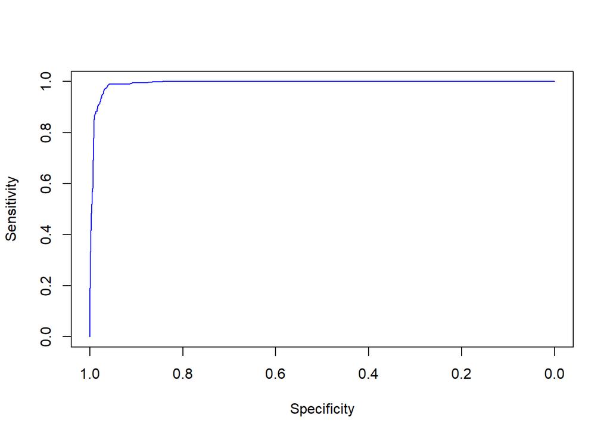

```r
plot(x = roc(predictor = svm$pred$malignant, response = svm$pred$obs)$specificities, y = roc(predictor = svm$pred$malignant, response = svm$pred$obs)$sensitivities, col= "blue", xlim = c(1, 0), type ="l", ylab = "Sensitivity", xlab = "Specificity")
```

## Test Set

```r
svm_test = predict(svm, newdata = test_classification)
confusionMatrix(svm_test, reference = test_classification$Class)
```

```
## Confusion Matrix and Statistics
##
##            Reference
## Prediction  benign malignant
##   benign       116         3
##   malignant      4        52
##
##                Accuracy : 0.96
##                  95% CI : (0.9193, 0.9838)
##     No Information Rate : 0.6857
##     P-Value [Acc > NIR] : <2e-16
##
##                   Kappa : 0.9077
##
##  Mcnemar's Test P-Value : 1
##
##             Sensitivity : 0.9667
##             Specificity : 0.9455
##          Pos Pred Value : 0.9748
##          Neg Pred Value : 0.9286
##              Prevalence : 0.6857
##          Detection Rate : 0.6629
##    Detection Prevalence : 0.6800
##       Balanced Accuracy : 0.9561
##
##        'Positive' Class : benign
##
```

## SVM with a radial kernel

```r
set.seed(1112)
control = trainControl(method = "repeatedcv", repeats = 5, classProbs = T, savePredictions = T)

svm = train(Class ~ Id + Cl.thickness + Cell.size + Cell.shape + Marg.adhesion + Epith.c.size + Bare.nuclei + Bl.cromatin + Normal.nucleoli +  Mitoses,  data = train_classification, method = "svmRadial", tuneLength = 10, trControl = control)

svm
```

```
## Support Vector Machines with Radial Basis Function Kernel
##
## 524 samples
##  10 predictor
##   2 classes: 'benign', 'malignant'
##
## No pre-processing
## Resampling: Cross-Validated (10 fold, repeated 5 times)
## Summary of sample sizes: 472, 472, 472, 471, 472, 471, ...
## Resampling results across tuning parameters:
##
##   C       Accuracy   Kappa
##     0.25  0.9558111  0.9062308
##     0.50  0.9596505  0.9141683
##     1.00  0.9577344  0.9099084
##     2.00  0.9535397  0.9008121
##     4.00  0.9539391  0.9016667
##     8.00  0.9550711  0.9041021
##    16.00  0.9546938  0.9033452
##    32.00  0.9535545  0.9008699
##    64.00  0.9546938  0.9033260
##   128.00  0.9543016  0.9024531
##
## Tuning parameter 'sigma' was held constant at a value of 0.5322765
## Accuracy was used to select the optimal model using the largest value.
## The final values used for the model were sigma = 0.5322765 and C = 0.5.
```

## Receiver operating characteristic(ROC) curve

```r
roc(predictor = svm$pred$malignant, response = svm$pred$obs)$auc
```

```
## Area under the curve: 0.983
```

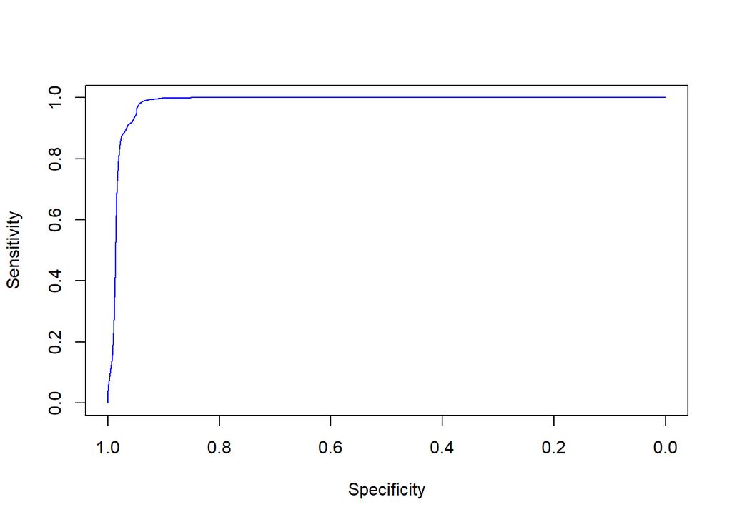

```r
plot(x = roc(predictor = svm$pred$malignant, response = svm$pred$obs)$specificities, y = roc(predictor = svm$pred$malignant, response = svm$pred$obs)$sensitivities, col= "blue", xlim = c(1, 0), type ="l", ylab = "Sensitivity", xlab = "Specificity")
```

## Test Set

```r
svm_test = predict(svm, newdata = test_classification)
confusionMatrix(svm_test, reference = test_classification$Class)
```

```
## Confusion Matrix and Statistics
##
##            Reference
## Prediction  benign malignant
##   benign       111         1
##   malignant      9        54
##
##                Accuracy : 0.9429
##                  95% CI : (0.8974, 0.9723)
##     No Information Rate : 0.6857
##     P-Value [Acc > NIR] : < 2e-16
##
##                   Kappa : 0.8724
##
##  Mcnemar's Test P-Value : 0.02686
##
##             Sensitivity : 0.9250
##             Specificity : 0.9818
##          Pos Pred Value : 0.9911
##          Neg Pred Value : 0.8571
##              Prevalence : 0.6857
##          Detection Rate : 0.6343
##    Detection Prevalence : 0.6400
##       Balanced Accuracy : 0.9534
##
##        'Positive' Class : benign
##
```

## Homework

1. Choose an appropriate machine learning dataset and use SVM with two different kernels. Campare the results.

SVM model with a linear kernel

```r
data("Carseats")
carseats = Carseats

#convert quantitative variable Sales into a binary response
High = ifelse(carseats$Sales<=8, "No", "Yes")
carseats = data.frame(carseats, High)

#set seed to make results reproducible
set.seed(29)

#split data into train and test subset (250 and 150 respectively)
train = sample(1:nrow(carseats), 250)

#Fit train subset of data to svm model with a linear kernel
control = trainControl(method = "repeatedcv", repeats = 5, classProbs = T, savePredictions = T)

svm.linear = train(High~.-Sales, carseats, subset=train, method = "svmLinear", tuneLength = 10, trControl = control)

svm.linear
```

```
## Support Vector Machines with Linear Kernel
##
## 400 samples
##  11 predictor
##   2 classes: 'No', 'Yes'
##
## No pre-processing
## Resampling: Cross-Validated (10 fold, repeated 5 times)
## Summary of sample sizes: 225, 225, 225, 225, 225, 225, ...
## Resampling results:
##
##   Accuracy   Kappa
##   0.8944051  0.7804477
##
## Tuning parameter 'C' was held constant at a value of 1
```

ROC curve for SVM model with a linear kernel

```r
roc(predictor = svm.linear$pred$Yes, response = svm.linear$pred$obs)$auc
```

```
## Area under the curve: 0.9605
```

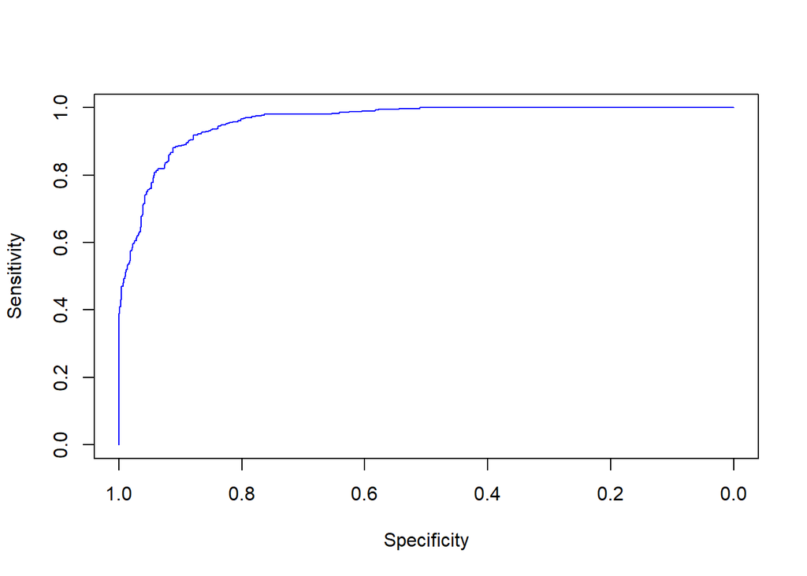

```r
plot(x = roc(predictor = svm.linear$pred$Yes, response = svm.linear$pred$obs)$specificities, y = roc(predictor = svm.linear$pred$Yes, response = svm.linear$pred$obs)$sensitivities, col= "blue", xlim = c(1, 0), type ="l", ylab = "Sensitivity", xlab = "Specificity")
```

Test set for SVM model with a linear kernel

```r
#set seed to make results reproducible
set.seed(29)

svm.linear_test = predict(svm.linear, newdata = carseats[-train,])
confusionMatrix(svm.linear_test, reference = carseats[-train,]$High)
```

```
## Confusion Matrix and Statistics
##
##           Reference
## Prediction No Yes
##        No  81  12
##        Yes  7  50
##
##                Accuracy : 0.8733
##                  95% CI : (0.8093, 0.922)
##     No Information Rate : 0.5867
##     P-Value [Acc > NIR] : 1.623e-14
##
##                   Kappa : 0.7357
##
##  Mcnemar's Test P-Value : 0.3588
##
##             Sensitivity : 0.9205
##             Specificity : 0.8065
##          Pos Pred Value : 0.8710
##          Neg Pred Value : 0.8772
##              Prevalence : 0.5867
##          Detection Rate : 0.5400
##    Detection Prevalence : 0.6200
##       Balanced Accuracy : 0.8635
##
##        'Positive' Class : No
##
```

SVM model with a radial kernel

```r
set.seed(1112)
control = trainControl(method = "repeatedcv", repeats = 5, classProbs = T, savePredictions = T)

svm.radial = train(High~.-Sales, carseats, subset=train, method = "svmRadial", tuneLength = 10, trControl = control)

svm.radial
```

```
## Support Vector Machines with Radial Basis Function Kernel
##
## 400 samples
##  11 predictor
##   2 classes: 'No', 'Yes'
##
## No pre-processing
## Resampling: Cross-Validated (10 fold, repeated 5 times)
## Summary of sample sizes: 226, 225, 224, 225, 225, 225, ...
## Resampling results across tuning parameters:
##
##   C       Accuracy   Kappa
##     0.25  0.8055333  0.6005060
##     0.50  0.8359462  0.6607489
##     1.00  0.8512821  0.6949467
##     2.00  0.8503897  0.6906938
##     4.00  0.8614641  0.7126748
##     8.00  0.8503256  0.6896356
##    16.00  0.8358897  0.6591071
##    32.00  0.8282667  0.6417081
##    64.00  0.8226000  0.6308221
##   128.00  0.8162333  0.6178430
##
## Tuning parameter 'sigma' was held constant at a value of 0.05545717
## Accuracy was used to select the optimal model using the largest value.
## The final values used for the model were sigma = 0.05545717 and C = 4.
```

ROC curve for SVM model with a radial kernel

```r
roc(predictor = svm.radial$pred$Yes, response = svm.radial$pred$obs)$auc
```

```
## Area under the curve: 0.9212
```

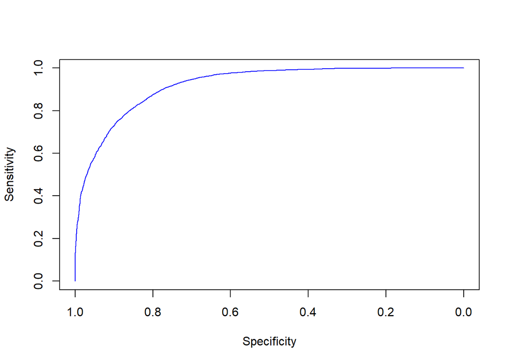

```r
plot(x = roc(predictor = svm.radial$pred$Yes, response = svm.radial$pred$obs)$specificities, y = roc(svm.radial$pred$Yes, response = svm.radial$pred$obs)$sensitivities, col= "blue", xlim = c(1, 0), type ="l", ylab = "Sensitivity", xlab = "Specificity")
```

Test set for SVM model with a radial kernel

```r
#set seed to make results reproducible
set.seed(29)

svm.radial_test = predict(svm.radial, newdata = carseats[-train,])
confusionMatrix(svm.radial_test, reference = carseats[-train,]$High)
```

```
## Confusion Matrix and Statistics
##
##           Reference
## Prediction No Yes
##        No  78   9
##        Yes 10  53
##
##                Accuracy : 0.8733
##                  95% CI : (0.8093, 0.922)
##     No Information Rate : 0.5867
##     P-Value [Acc > NIR] : 1.623e-14
##
##                   Kappa : 0.7394
##
##  Mcnemar's Test P-Value : 1
##
##             Sensitivity : 0.8864
##             Specificity : 0.8548
##          Pos Pred Value : 0.8966
##          Neg Pred Value : 0.8413
##              Prevalence : 0.5867
##          Detection Rate : 0.5200
##    Detection Prevalence : 0.5800
##       Balanced Accuracy : 0.8706
##
##        'Positive' Class : No
##
```